```r
# SISTEMA DE CONCORDANCIA DE GÉNERO PARA MASCOTAS
# Definir mascotas con su género gramatical
mascotas_masculinas <- c('loro', 'perro', 'gato', 'hamster', 'cerdo', 'ternero', 'caballo',
                        'conejo', 'pez', 'canario', 'hurón', 'ratón', 'camaleón', 'pato',
                        'pavo', 'burro', 'ganso', 'cisne', 'lagarto', 'erizo')

mascotas_femeninas <- c('gallina', 'cabra', 'tortuga', 'iguana', 'serpiente', 'araña',
                       'oveja', 'vaca', 'paloma')

# Combinar todas las mascotas
mascotas <- c(mascotas_masculinas, mascotas_femeninas)

# Crear función para determinar el artículo correcto
obtener_articulo <- function(animal) {
  if (animal %in% mascotas_masculinas) {
    return("un")
  } else if (animal %in% mascotas_femeninas) {
    return("una")
  } else {
    return("un(a)")  # Fallback por si acaso
  }
}

# Shuffle the mascotas vector
mascotas <- sample(mascotas)

# Seleccionar una muestra aleatoria de 3 elementos sin repetición
selmascota <- sample(mascotas, 3)

nombremascota1 <- selmascota[1]
nombremascota2 <- selmascota[2]
nombremascota3 <- selmascota[3]

# Crear secuencia del 60 al 300 de 10 en 10
numeros <- seq(60, 600, 10)

# Eliminamos el número 100 del vector
numeros_sin_100 <- setdiff(numeros, 100)

# Ahora hacemos el muestreo de este nuevo vector
enkuestados <- sample(numeros_sin_100, 1)

# Ensure that enkuestados is a multiple of 10
enkuestados <- enkuestados - (enkuestados %% 10)
```

```r
# Generar tres números para los porcentajes. Su suma siempre debe ser igual a 100
generar_vector_unico <- function() {
  repetir <- TRUE
  while (repetir) {
    # Generar el primer número como un múltiplo de 5 entre 5 y 60.
    # Esto aumenta las posibilidades de tener tres números únicos.
    primer_numero <- sample(seq(5, 60, by = 5), 1)

    # Calcular el máximo valor posible para el segundo número,
    # asegurándose de que haya espacio para un tercer número único.
    max_segundo_numero <- 95 - primer_numero

    # Generar el segundo número asegurando que sea diferente al primero
    posibles_segundos <- seq(5, max_segundo_numero, by = 5)
    posibles_segundos <- posibles_segundos[posibles_segundos != primer_numero]
    if (length(posibles_segundos) > 0) {
      segundo_numero <- sample(posibles_segundos, 1)
    } else {
      next
    }

    # Calcular el tercer número necesario para que la suma sea 100,
    # asegurándose de que sea diferente a los dos anteriores.
    tercer_numero <- 100 - primer_numero - segundo_numero

    # Verificar si los tres números son únicos
    if (length(unique(c(primer_numero, segundo_numero, tercer_numero))) == 3) {
      repetir <- FALSE
    }
  }

  # Crear el vector
  vector <- c(primer_numero, segundo_numero, tercer_numero)

  return(vector)
}

# Generar y mostrar el vector de porcentajes
vector_resultado <- generar_vector_unico()

mashor <- max(vector_resultado)

porxentaje1 <- vector_resultado[1]
porxentaje2 <- vector_resultado[2]
porxentaje3 <- vector_resultado[3]
####################################################

maskota1 <- (enkuestados*vector_resultado[1])/100 # Número de personas que adoptan maskota1
maskota2 <- (enkuestados*vector_resultado[2])/100
maskota3 <- (enkuestados*vector_resultado[3])/100

mashiormaskota <- max(maskota1, maskota2, maskota3)
```

```r
# TABLA OPTIMIZADA PARA DOS COLUMNAS - MÁS PEQUEÑA
image01 <- '
\\begin{tikzpicture}[scale=0.8]
  \\node{
\\begin{tabular}{|l|c|}
\\hline
\\scriptsize\\textbf{Animal} & \\scriptsize\\textbf{Cantidad de personas } \\\\
     & \\scriptsize\\textbf{interesadas en adoptar} \\\\ \\hline
\\scriptsize %s & \\scriptsize %s \\\\ \\hline
\\scriptsize %s & \\scriptsize %s \\\\ \\hline
\\scriptsize %s & \\scriptsize %s \\\\ \\hline
\\end{tabular}
};
\\end{tikzpicture}
'

demas <- sample

maskota1_format <- smart_format_decimal(maskota1)
maskota2_format <- smart_format_decimal(maskota2)
maskota3_format <- smart_format_decimal(maskota3)

image01 <-sprintf(image01, selmascota[1], maskota1_format, selmascota[2], maskota2_format, selmascota[3], maskota3_format)
```

# Question

El líder de un programa de adopción de mascotas encuestó a 600 personas para conocer qué animal les interesaría adoptar. Del total de encuestados, el 20% adoptaría un pez, el 45% adoptaría un pato y el 35% adoptaría un canario.

¿Cuál de las siguientes representaciones NO muestra correctamente la información recolectada en la encuesta?

## Answerlist

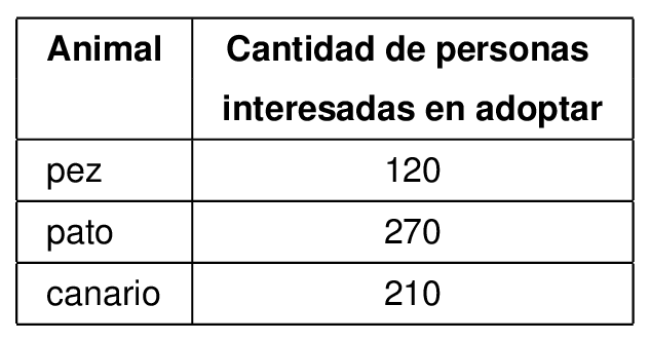

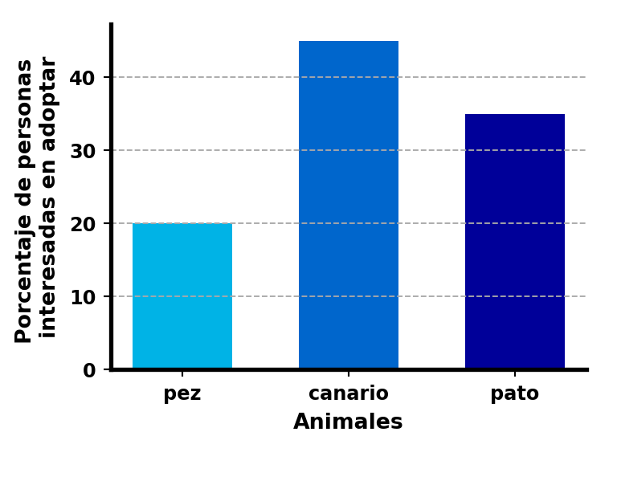

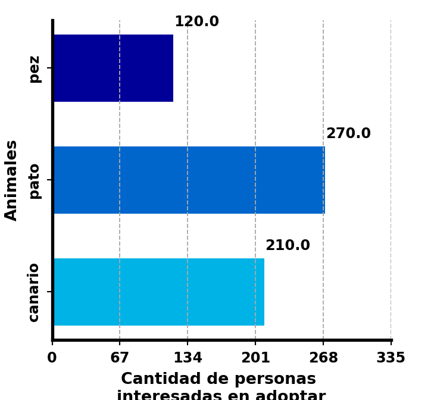

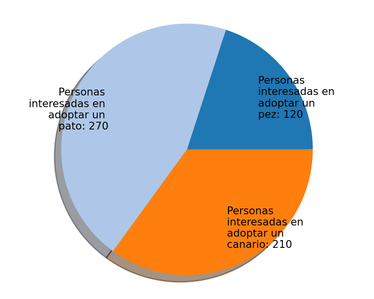

# Solution

La representación que **NO muestra correctamente** la información recolectada en la encuesta es el **gráfico de barras verticales**.

**Análisis de las representaciones:**

- **Tabla**: **Correcta**. Aunque muestra números absolutos de personas, estos corresponden correctamente a los porcentajes mencionados en la encuesta.
- **Gráfico de barras verticales**: **Incorrecto**. Aunque la etiqueta del eje Y indica “Porcentaje de personas interesadas en adoptar”, los datos o la correspondencia de animales no coinciden correctamente con la información de la encuesta.
- **Gráfico de barras horizontales**: **Correcto**. Muestra números absolutos de personas que corresponden correctamente a los porcentajes de la encuesta.
- **Gráfico de torta**: **Correcto**. Muestra correctamente la distribución proporcional usando números absolutos que corresponden a los porcentajes mencionados.

**Por lo tanto, el gráfico de barras verticales es el único que NO muestra correctamente la información, mientras que las demás opciones SÍ la representan correctamente.**

**La gráfica incorrecta es:**

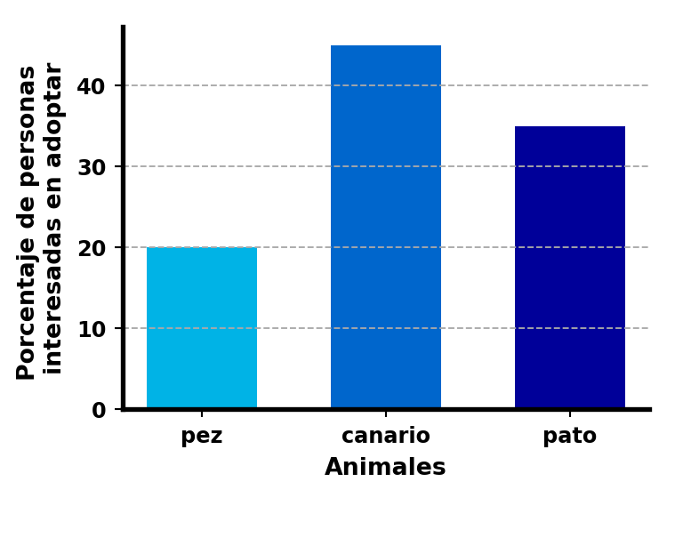

# Meta-information

exname: I_1796473/2023-Cuadernillo-Matematicas-11-2(single-choice) extype: schoice exsolution: 0100 exshuffle: TRUE